# Data Analytics For How Does a Bike-Share Navigate Speedy Success

Nikhil Sharma

2022-08-09

## Data Analytics For How Does a Bike-Share Navigate Speedy Success? A Case Study

**Nikhil Sharma** Center for computer and Communication Technology, Chisopani, Sikkim  
Google/ Data Analytics Professional Certificate - Coursera

#### Keywords:

Data Analytics, Bike-Share, Succcess, Case Study

## Introduction

This exploratory analysis case study is towards Capstone project requirement for Google Data Analytics Professional Certificate. The case study involves a bikeshare company’s data of its customer’s trip details over a 12 month period (August 2021 - July 2022). The data has been made available by Motivate International Inc. under this license.

The analysis will follow the 6 phases of the Data Analysis process by the Google: Ask, Prepare, Process, Analyze, Share, and Act.

A brief explanation of these 6 phases:

##### Ask

- Ask effective questions
- Define the scope of the analysis
- Define what success looks like

##### Prepare

- Verify data’s integrity
- Check data credibility and reliability
- Check data types
- Merge datasets

##### Process

- Clean, Remove and Transform data
- Document cleaning processes and results

##### Analyze

- Identify patterns
- Draw conclusions
- Make predictions

##### Share

- Create effective visuals
- Create a story for data
- Share insights to stakeholders

##### Act

- Give recommendations based on insights
- Solve problems
- Create something new

## 1. Business Understanding

The focus of this section is to understand the basic concepts of our Bike-share company. Project objectives are derived from the Director of Marketing and later converted into data science problem definitions.

##### Scenario

###### Please note that this is a fictional case study.

In 2016, Cyclistic launched a successful bike-share offering. Since then, the program has grown to a fleet of 5,824 bicycles that are geotracked and locked into a network of 692 stations across Chicago. The bikes can be unlocked from one station and returned to any other station in the system anytime.

Until now, Cyclistic’s marketing strategy relied on building general awareness and appealing to broad consumer segments. One approach that helped make these things possible was the flexibility of its pricing plans: single-ride passes, full-day passes, and annual memberships. Customers who purchase single-ride or full-day passes are referred to as casual riders. Customers who purchase annual memberships are Cyclistic members.

Cyclistic’s finance analysts have concluded that annual members are much more profitable than casual riders. Although the pricing flexibility helps Cyclistic attract more customers, Moreno believes that maximizing the number of annual members will be key to future growth. Rather than creating a marketing campaign that targets all-new customers, Director of Marketing believes there is a very good chance to convert casual riders into members. She/He notes that casual riders are already aware of the Cyclistic program and have chosen Cyclistic for their mobility needs.

Director of Marketing has set a clear goal: Design marketing strategies aimed at converting casual riders into annual members. In order to do that, however, the marketing analyst team needs to better understand how annual members and casual riders differ, why casual riders would buy a membership, and how digital media could affect their marketing tactics.

Marketing team needs to design marketing strategies aimed at converting casual riders into annual members. In order to do that, however, the marketing analyst team needs to better understand how annual members and casual riders differ.

Director of Marketing has assigned me the first question to answer: How do annual members and casual riders use Cyclistic bikes differently?

##### Stakeholders

- Director of Marketing
- Cyclist Executive Team

##### Objective

Hence, the objective for this analysis is to throw some light on how the two types of customers: annual members and casual riders, use Cyclistic bikes-hare differently, based on few parameters that can be calculated/ obtained from existing data.

## 2. Data Understanding

This section starts with initial data collection and proceeds with activities that targets understanding the data. These activities include ﬁrst insight into the data, identifying data for analytic purposes, discovering data quality issues and/or detecting interesting subsets to form hypothesis regarding previously un-detected patterns.

##### Documentation, Cleaning and Preparation of data for analysis

The combined size of all the 12 datasets which is massive in size. Data cleaning in spreadsheets will be time-consuming and slow compared to SQL or R. I am choosing R simply because I could do both data wrangling and analysis/ visualizations in the same platform. It is also an opportunity for me to learn R in a better way.

## 3. Data Preparation

This section provides insight into the business problems before performing data modeling. The data preparation phase include activities, such as data selection, data transformation, data cleaning and data validation. Data preparation tasks may be performed several times and not in any given order. During this phase important issues are addressed like selecting the relevant data, cleaning of data, discarding unacceptable data and how the ERP system data can be integrated into the ﬁnal data sets.

#### Loading libraries

```r
library(tidyverse)
```

```r
library(ggplot2)
library(lubridate)
library(dplyr)
library(geosphere)
library(readr)
library(janitor)
library(data.table)
library(tidyr)
library(scales)
```

#### Load the 12 Datasets in different variable

The 12-month historical trip data (in CSV format) are extracted and stored in one folder titled “bike_share_data”. Next, the 12 CSV files are merged into one dataframe called “cyclist_data” by executing the following code:

```r
tripdata_202108 <- read.csv("./Bike_share_data/202108-divvy-tripdata.csv")
tripdata_202109 <- read.csv("./Bike_share_data/202109-divvy-tripdata.csv")
tripdata_202110 <- read.csv("./Bike_share_data/202110-divvy-tripdata.csv")
tripdata_202111 <- read.csv("./Bike_share_data/202111-divvy-tripdata.csv")
tripdata_202112 <- read.csv("./Bike_share_data/202112-divvy-tripdata.csv")
tripdata_202201 <- read.csv("./Bike_share_data/202201-divvy-tripdata.csv")
tripdata_202202 <- read.csv("./Bike_share_data/202202-divvy-tripdata.csv")
tripdata_202203 <- read.csv("./Bike_share_data/202203-divvy-tripdata.csv")
tripdata_202204 <- read.csv("./Bike_share_data/202204-divvy-tripdata.csv")
tripdata_202205 <- read.csv("./Bike_share_data/202205-divvy-tripdata.csv")
tripdata_202206 <- read.csv("./Bike_share_data/202206-divvy-tripdata.csv")
tripdata_202207 <- read.csv("./Bike_share_data/202207-divvy-tripdata.csv")
```

#### Check data structures and data types for all data frames for data integrity

```r
str(tripdata_202108)
```

```
## 'data.frame':    804352 obs. of  13 variables:
##  $ ride_id           : chr  "99103BB87CC6C1BB" "EAFCCCFB0A3FC5A1" "9EF4F46C57AD234D" "5834D3208BFAF1DA" ...
##  $ rideable_type     : chr  "electric_bike" "electric_bike" "electric_bike" "electric_bike" ...
##  $ started_at        : chr  "10-08-2021 17:15" "10-08-2021 17:23" "21-08-2021 02:34" "21-08-2021 06:52" ...
##  $ ended_at          : chr  "10-08-2021 17:22" "10-08-2021 17:39" "21-08-2021 02:50" "21-08-2021 07:08" ...
##  $ start_station_name: chr  "" "" "" "" ...
##  $ start_station_id  : chr  "" "" "" "" ...
##  $ end_station_name  : chr  "" "" "" "" ...
##  $ end_station_id    : chr  "" "" "" "" ...
##  $ start_lat         : num  41.8 41.8 42 42 41.8 ...
##  $ start_lng         : num  -87.7 -87.7 -87.7 -87.7 -87.6 ...
##  $ end_lat           : num  41.8 41.8 42 42 41.8 ...
##  $ end_lng           : num  -87.7 -87.6 -87.7 -87.7 -87.6 ...
##  $ member_casual     : chr  "member" "member" "member" "member" ...
```

```r
str(tripdata_202109)
```

```
## 'data.frame':    756147 obs. of  13 variables:
##  $ ride_id           : chr  "9DC7B962304CBFD8" "F930E2C6872D6B32" "6EF72137900BB910" "78D1DE133B3DBF55" ...
##  $ rideable_type     : chr  "electric_bike" "electric_bike" "electric_bike" "electric_bike" ...
##  $ started_at        : chr  "2021-09-28 16:07:10" "2021-09-28 14:24:51" "2021-09-28 00:20:16" "2021-09-28 14:51:17" ...
##  $ ended_at          : chr  "2021-09-28 16:09:54" "2021-09-28 14:40:05" "2021-09-28 00:23:57" "2021-09-28 15:00:06" ...
##  $ start_station_name: chr  "" "" "" "" ...
##  $ start_station_id  : chr  "" "" "" "" ...
##  $ end_station_name  : chr  "" "" "" "" ...
##  $ end_station_id    : chr  "" "" "" "" ...
##  $ start_lat         : num  41.9 41.9 41.8 41.8 41.9 ...
##  $ start_lng         : num  -87.7 -87.6 -87.7 -87.7 -87.7 ...
##  $ end_lat           : num  41.9 42 41.8 41.8 41.9 ...
##  $ end_lng           : num  -87.7 -87.7 -87.7 -87.7 -87.7 ...
##  $ member_casual     : chr  "casual" "casual" "casual" "casual" ...
```

```r
str(tripdata_202110)
```

```
## 'data.frame':    631226 obs. of  13 variables:
##  $ ride_id           : chr  "620BC6107255BF4C" "4471C70731AB2E45" "26CA69D43D15EE14" "362947F0437E1514" ...
##  $ rideable_type     : chr  "electric_bike" "electric_bike" "electric_bike" "electric_bike" ...
##  $ started_at        : chr  "2021-10-22 12:46:42" "2021-10-21 09:12:37" "2021-10-16 16:28:39" "2021-10-16 16:17:48" ...
##  $ ended_at          : chr  "2021-10-22 12:49:50" "2021-10-21 09:14:14" "2021-10-16 16:36:26" "2021-10-16 16:19:03" ...
##  $ start_station_name: chr  "Kingsbury St & Kinzie St" "" "" "" ...
##  $ start_station_id  : chr  "KA1503000043" "" "" "" ...
##  $ end_station_name  : chr  "" "" "" "" ...
##  $ end_station_id    : chr  "" "" "" "" ...
##  $ start_lat         : num  41.9 41.9 41.9 41.9 41.9 ...
##  $ start_lng         : num  -87.6 -87.7 -87.7 -87.7 -87.7 ...
##  $ end_lat           : num  41.9 41.9 41.9 41.9 41.9 ...
##  $ end_lng           : num  -87.6 -87.7 -87.7 -87.7 -87.7 ...
##  $ member_casual     : chr  "member" "member" "member" "member" ...
```

```r
str(tripdata_202111)
```

```
## 'data.frame':    359978 obs. of  13 variables:
##  $ ride_id           : chr  "7C00A93E10556E47" "90854840DFD508BA" "0A7D10CDD144061C" "2F3BE33085BCFF02" ...
##  $ rideable_type     : chr  "electric_bike" "electric_bike" "electric_bike" "electric_bike" ...
##  $ started_at        : chr  "2021-11-27 13:27:38" "2021-11-27 13:38:25" "2021-11-26 22:03:34" "2021-11-27 09:56:49" ...
##  $ ended_at          : chr  "2021-11-27 13:46:38" "2021-11-27 13:56:10" "2021-11-26 22:05:56" "2021-11-27 10:01:50" ...
##  $ start_station_name: chr  "" "" "" "" ...
##  $ start_station_id  : chr  "" "" "" "" ...
##  $ end_station_name  : chr  "" "" "" "" ...
##  $ end_station_id    : chr  "" "" "" "" ...
##  $ start_lat         : num  41.9 42 42 41.9 41.9 ...
##  $ start_lng         : num  -87.7 -87.7 -87.7 -87.8 -87.6 ...
##  $ end_lat           : num  42 41.9 42 41.9 41.9 ...
##  $ end_lng           : num  -87.7 -87.7 -87.7 -87.8 -87.6 ...
##  $ member_casual     : chr  "casual" "casual" "casual" "casual" ...
```

```r
str(tripdata_202112)
```

```
## 'data.frame':    247540 obs. of  13 variables:
##  $ ride_id           : chr  "46F8167220E4431F" "73A77762838B32FD" "4CF42452054F59C5" "3278BA87BF698339" ...
##  $ rideable_type     : chr  "electric_bike" "electric_bike" "electric_bike" "classic_bike" ...
##  $ started_at        : chr  "2021-12-07 15:06:07" "2021-12-11 03:43:29" "2021-12-15 23:10:28" "2021-12-26 16:16:10" ...
##  $ ended_at          : chr  "2021-12-07 15:13:42" "2021-12-11 04:10:23" "2021-12-15 23:23:14" "2021-12-26 16:30:53" ...
##  $ start_station_name: chr  "Laflin St & Cullerton St" "LaSalle Dr & Huron St" "Halsted St & North Branch St" "Halsted St & North Branch St" ...
##  $ start_station_id  : chr  "13307" "KP1705001026" "KA1504000117" "KA1504000117" ...
##  $ end_station_name  : chr  "Morgan St & Polk St" "Clarendon Ave & Leland Ave" "Broadway & Barry Ave" "LaSalle Dr & Huron St" ...
##  $ end_station_id    : chr  "TA1307000130" "TA1307000119" "13137" "KP1705001026" ...
##  $ start_lat         : num  41.9 41.9 41.9 41.9 41.9 ...
##  $ start_lng         : num  -87.7 -87.6 -87.6 -87.6 -87.7 ...
##  $ end_lat           : num  41.9 42 41.9 41.9 41.9 ...
##  $ end_lng           : num  -87.7 -87.7 -87.6 -87.6 -87.6 ...
##  $ member_casual     : chr  "member" "casual" "member" "member" ...
```

```r
str(tripdata_202201)
```

```
## 'data.frame':    103770 obs. of  13 variables:
##  $ ride_id           : chr  "C2F7DD78E82EC875" "A6CF8980A652D272" "BD0F91DFF741C66D" "CBB80ED419105406" ...
##  $ rideable_type     : chr  "electric_bike" "electric_bike" "classic_bike" "classic_bike" ...
##  $ started_at        : chr  "2022-01-13 11:59:47" "2022-01-10 08:41:56" "2022-01-25 04:53:40" "2022-01-04 00:18:04" ...
##  $ ended_at          : chr  "2022-01-13 12:02:44" "2022-01-10 08:46:17" "2022-01-25 04:58:01" "2022-01-04 00:33:00" ...
##  $ start_station_name: chr  "Glenwood Ave & Touhy Ave" "Glenwood Ave & Touhy Ave" "Sheffield Ave & Fullerton Ave" "Clark St & Bryn Mawr Ave" ...
##  $ start_station_id  : chr  "525" "525" "TA1306000016" "KA1504000151" ...
##  $ end_station_name  : chr  "Clark St & Touhy Ave" "Clark St & Touhy Ave" "Greenview Ave & Fullerton Ave" "Paulina St & Montrose Ave" ...
##  $ end_station_id    : chr  "RP-007" "RP-007" "TA1307000001" "TA1309000021" ...
##  $ start_lat         : num  42 42 41.9 42 41.9 ...
##  $ start_lng         : num  -87.7 -87.7 -87.7 -87.7 -87.6 ...
##  $ end_lat           : num  42 42 41.9 42 41.9 ...
##  $ end_lng           : num  -87.7 -87.7 -87.7 -87.7 -87.6 ...
##  $ member_casual     : chr  "casual" "casual" "member" "casual" ...
```

```r
str(tripdata_202202)
```

```
## 'data.frame':    115609 obs. of  13 variables:
##  $ ride_id           : chr  "E1E065E7ED285C02" "1602DCDC5B30FFE3" "BE7DD2AF4B55C4AF" "A1789BDF844412BE" ...
##  $ rideable_type     : chr  "classic_bike" "classic_bike" "classic_bike" "classic_bike" ...
##  $ started_at        : chr  "2022-02-19 18:08:41" "2022-02-20 17:41:30" "2022-02-25 18:55:56" "2022-02-14 11:57:03" ...
##  $ ended_at          : chr  "2022-02-19 18:23:56" "2022-02-20 17:45:56" "2022-02-25 19:09:34" "2022-02-14 12:04:00" ...
##  $ start_station_name: chr  "State St & Randolph St" "Halsted St & Wrightwood Ave" "State St & Randolph St" "Southport Ave & Waveland Ave" ...
##  $ start_station_id  : chr  "TA1305000029" "TA1309000061" "TA1305000029" "13235" ...
##  $ end_station_name  : chr  "Clark St & Lincoln Ave" "Southport Ave & Wrightwood Ave" "Canal St & Adams St" "Broadway & Sheridan Rd" ...
##  $ end_station_id    : chr  "13179" "TA1307000113" "13011" "13323" ...
##  $ start_lat         : num  41.9 41.9 41.9 41.9 41.9 ...
##  $ start_lng         : num  -87.6 -87.6 -87.6 -87.7 -87.6 ...
##  $ end_lat           : num  41.9 41.9 41.9 42 41.9 ...
##  $ end_lng           : num  -87.6 -87.7 -87.6 -87.6 -87.6 ...
##  $ member_casual     : chr  "member" "member" "member" "member" ...
```

```r
str(tripdata_202203)
```

```
## 'data.frame':    284042 obs. of  13 variables:
##  $ ride_id           : chr  "47EC0A7F82E65D52" "8494861979B0F477" "EFE527AF80B66109" "9F446FD9DEE3F389" ...
##  $ rideable_type     : chr  "classic_bike" "electric_bike" "classic_bike" "classic_bike" ...
##  $ started_at        : chr  "2022-03-21 13:45:01" "2022-03-16 09:37:16" "2022-03-23 19:52:02" "2022-03-01 19:12:26" ...
##  $ ended_at          : chr  "2022-03-21 13:51:18" "2022-03-16 09:43:34" "2022-03-23 19:54:48" "2022-03-01 19:22:14" ...
##  $ start_station_name: chr  "Wabash Ave & Wacker Pl" "Michigan Ave & Oak St" "Broadway & Berwyn Ave" "Wabash Ave & Wacker Pl" ...
##  $ start_station_id  : chr  "TA1307000131" "13042" "13109" "TA1307000131" ...
##  $ end_station_name  : chr  "Kingsbury St & Kinzie St" "Orleans St & Chestnut St (NEXT Apts)" "Broadway & Ridge Ave" "Franklin St & Jackson Blvd" ...
##  $ end_station_id    : chr  "KA1503000043" "620" "15578" "TA1305000025" ...
##  $ start_lat         : num  41.9 41.9 42 41.9 41.9 ...
##  $ start_lng         : num  -87.6 -87.6 -87.7 -87.6 -87.6 ...
##  $ end_lat           : num  41.9 41.9 42 41.9 41.9 ...
##  $ end_lng           : num  -87.6 -87.6 -87.7 -87.6 -87.7 ...
##  $ member_casual     : chr  "member" "member" "member" "member" ...
```

```r
str(tripdata_202204)
```

```
## 'data.frame':    371249 obs. of  13 variables:
##  $ ride_id           : chr  "3564070EEFD12711" "0B820C7FCF22F489" "89EEEE32293F07FF" "84D4751AEB31888D" ...
##  $ rideable_type     : chr  "electric_bike" "classic_bike" "classic_bike" "classic_bike" ...
##  $ started_at        : chr  "2022-04-06 17:42:48" "2022-04-24 19:23:07" "2022-04-20 19:29:08" "2022-04-22 21:14:06" ...
##  $ ended_at          : chr  "2022-04-06 17:54:36" "2022-04-24 19:43:17" "2022-04-20 19:35:16" "2022-04-22 21:23:29" ...
##  $ start_station_name: chr  "Paulina St & Howard St" "Wentworth Ave & Cermak Rd" "Halsted St & Polk St" "Wentworth Ave & Cermak Rd" ...
##  $ start_station_id  : chr  "515" "13075" "TA1307000121" "13075" ...
##  $ end_station_name  : chr  "University Library (NU)" "Green St & Madison St" "Green St & Madison St" "Delano Ct & Roosevelt Rd" ...
##  $ end_station_id    : chr  "605" "TA1307000120" "TA1307000120" "KA1706005007" ...
##  $ start_lat         : num  42 41.9 41.9 41.9 41.9 ...
##  $ start_lng         : num  -87.7 -87.6 -87.6 -87.6 -87.6 ...
##  $ end_lat           : num  42.1 41.9 41.9 41.9 41.9 ...
##  $ end_lng           : num  -87.7 -87.6 -87.6 -87.6 -87.6 ...
##  $ member_casual     : chr  "member" "member" "member" "casual" ...
```

```r
str(tripdata_202205)
```

```
## 'data.frame':    634858 obs. of  13 variables:
##  $ ride_id           : chr  "EC2DE40644C6B0F4" "1C31AD03897EE385" "1542FBEC830415CF" "6FF59852924528F8" ...
##  $ rideable_type     : chr  "classic_bike" "classic_bike" "classic_bike" "classic_bike" ...
##  $ started_at        : chr  "2022-05-23 23:06:58" "2022-05-11 08:53:28" "2022-05-26 18:36:28" "2022-05-10 07:30:07" ...
##  $ ended_at          : chr  "2022-05-23 23:40:19" "2022-05-11 09:31:22" "2022-05-26 18:58:18" "2022-05-10 07:38:49" ...
##  $ start_station_name: chr  "Wabash Ave & Grand Ave" "DuSable Lake Shore Dr & Monroe St" "Clinton St & Madison St" "Clinton St & Madison St" ...
##  $ start_station_id  : chr  "TA1307000117" "13300" "TA1305000032" "TA1305000032" ...
##  $ end_station_name  : chr  "Halsted St & Roscoe St" "Field Blvd & South Water St" "Wood St & Milwaukee Ave" "Clark St & Randolph St" ...
##  $ end_station_id    : chr  "TA1309000025" "15534" "13221" "TA1305000030" ...
##  $ start_lat         : num  41.9 41.9 41.9 41.9 41.9 ...
##  $ start_lng         : num  -87.6 -87.6 -87.6 -87.6 -87.6 ...
##  $ end_lat           : num  41.9 41.9 41.9 41.9 41.9 ...
##  $ end_lng           : num  -87.6 -87.6 -87.7 -87.6 -87.7 ...
##  $ member_casual     : chr  "member" "member" "member" "member" ...
```

```r
str(tripdata_202206)
```

```
## 'data.frame':    769204 obs. of  13 variables:
##  $ ride_id           : chr  "600CFD130D0FD2A4" "F5E6B5C1682C6464" "B6EB6D27BAD771D2" "C9C320375DE1D5C6" ...
##  $ rideable_type     : chr  "electric_bike" "electric_bike" "electric_bike" "electric_bike" ...
##  $ started_at        : chr  "2022-06-30 17:27:53" "2022-06-30 18:39:52" "2022-06-30 11:49:25" "2022-06-30 11:15:25" ...
##  $ ended_at          : chr  "2022-06-30 17:35:15" "2022-06-30 18:47:28" "2022-06-30 12:02:54" "2022-06-30 11:19:43" ...
##  $ start_station_name: chr  "" "" "" "" ...
##  $ start_station_id  : chr  "" "" "" "" ...
##  $ end_station_name  : chr  "" "" "" "" ...
##  $ end_station_id    : chr  "" "" "" "" ...
##  $ start_lat         : num  41.9 41.9 41.9 41.8 41.9 ...
##  $ start_lng         : num  -87.6 -87.6 -87.7 -87.7 -87.6 ...
##  $ end_lat           : num  41.9 41.9 41.9 41.8 41.9 ...
##  $ end_lng           : num  -87.6 -87.6 -87.6 -87.7 -87.6 ...
##  $ member_casual     : chr  "casual" "casual" "casual" "casual" ...
```

```r
str(tripdata_202207)
```

```
## 'data.frame':    823489 obs. of  13 variables:
##  $ ride_id           : chr  "292E027607D218B6" "57765852588AD6E0" "B5B6BE44314590E6" "315FEBB7B3F6D2EA" ...
##  $ rideable_type     : chr  "classic_bike" "classic_bike" "classic_bike" "classic_bike" ...
##  $ started_at        : chr  "26-07-2022 12:53" "03-07-2022 13:58" "31-07-2022 17:44" "28-07-2022 20:38" ...
##  $ ended_at          : chr  "26-07-2022 12:55" "03-07-2022 14:06" "31-07-2022 18:42" "28-07-2022 21:09" ...
##  $ start_station_name: chr  "Buckingham Fountain (Temp)" "Buckingham Fountain (Temp)" "Buckingham Fountain (Temp)" "Wabash Ave & Grand Ave" ...
##  $ start_station_id  : chr  "15541" "15541" "15541" "TA1307000117" ...
##  $ end_station_name  : chr  "Michigan Ave & 8th St" "Michigan Ave & 8th St" "Woodlawn Ave & 55th St" "Dearborn Pkwy & Delaware Pl" ...
##  $ end_station_id    : chr  "623" "623" "TA1307000164" "TA1307000128" ...
##  $ start_lat         : chr  "41.86962075" "41.86962075" "41.86962075" "41.891466" ...
##  $ start_lng         : chr  "-87.62398124" "-87.62398124" "-87.62398124" "-87.626761" ...
##  $ end_lat           : chr  "41.872773" "41.872773" "41.795264" "41.898969" ...
##  $ end_lng           : chr  "-87.623981" "-87.623981" "-87.596471" "-87.629912" ...
##  $ member_casual     : chr  "casual" "casual" "casual" "casual" ...
```

### Data transformation and cleaning

```r
tripdata_202207 <- tripdata_202207 %>% mutate(start_lat = as.integer(start_lat),start_lng = as.integer(start_lng), end_lat = as.integer(end_lat), end_lng = as.integer(end_lng))
```

### Combining the different datasets into one single dataframe

```r
  all_trips <- bind_rows(tripdata_202108, tripdata_202109, tripdata_202110, tripdata_202111, tripdata_202112, tripdata_202201, tripdata_202202, tripdata_202203, tripdata_202204, tripdata_202205,tripdata_202206, tripdata_202207)

str(all_trips)
```

```
## 'data.frame':    5901464 obs. of  13 variables:
##  $ ride_id           : chr  "99103BB87CC6C1BB" "EAFCCCFB0A3FC5A1" "9EF4F46C57AD234D" "5834D3208BFAF1DA" ...
##  $ rideable_type     : chr  "electric_bike" "electric_bike" "electric_bike" "electric_bike" ...
##  $ started_at        : chr  "10-08-2021 17:15" "10-08-2021 17:23" "21-08-2021 02:34" "21-08-2021 06:52" ...
##  $ ended_at          : chr  "10-08-2021 17:22" "10-08-2021 17:39" "21-08-2021 02:50" "21-08-2021 07:08" ...
##  $ start_station_name: chr  "" "" "" "" ...
##  $ start_station_id  : chr  "" "" "" "" ...
##  $ end_station_name  : chr  "" "" "" "" ...
##  $ end_station_id    : chr  "" "" "" "" ...
##  $ start_lat         : num  41.8 41.8 42 42 41.8 ...
##  $ start_lng         : num  -87.7 -87.7 -87.7 -87.7 -87.6 ...
##  $ end_lat           : num  41.8 41.8 42 42 41.8 ...
##  $ end_lng           : num  -87.7 -87.6 -87.7 -87.7 -87.6 ...
##  $ member_casual     : chr  "member" "member" "member" "member" ...
```

### Further Cleaning Up!

As we checked the structure of dataframe “all_trips” we found that started_at & ended_at is in ‘char’ data type instead of ‘datetime’ data type. Lets convert them to right data types.

```r
all_trips[['started_at']] <- ymd_hms(all_trips[['started_at']])
all_trips[['ended_at']] <- ymd_hms(all_trips[['ended_at']])
str(all_trips)
```

```
## 'data.frame':    5901464 obs. of  13 variables:
##  $ ride_id           : chr  "99103BB87CC6C1BB" "EAFCCCFB0A3FC5A1" "9EF4F46C57AD234D" "5834D3208BFAF1DA" ...
##  $ rideable_type     : chr  "electric_bike" "electric_bike" "electric_bike" "electric_bike" ...
##  $ started_at        : POSIXct, format: "2010-08-20 21:17:15" "2010-08-20 21:17:23" ...
##  $ ended_at          : POSIXct, format: "2010-08-20 21:17:22" "2010-08-20 21:17:39" ...
##  $ start_station_name: chr  "" "" "" "" ...
##  $ start_station_id  : chr  "" "" "" "" ...
##  $ end_station_name  : chr  "" "" "" "" ...
##  $ end_station_id    : chr  "" "" "" "" ...
##  $ start_lat         : num  41.8 41.8 42 42 41.8 ...
##  $ start_lng         : num  -87.7 -87.7 -87.7 -87.7 -87.6 ...
##  $ end_lat           : num  41.8 41.8 42 42 41.8 ...
##  $ end_lng           : num  -87.7 -87.6 -87.7 -87.7 -87.6 ...
##  $ member_casual     : chr  "member" "member" "member" "member" ...
```

### Now we should rename the columns name for better readablity and undersrtanding

While renaming don’t forget to overwrite your variable again to use it later because rename() function change the name just for current use of code. So, it is better to store the change in our variable after each code you run!

```r
all_trips <- all_trips %>%
    rename(ride_type = rideable_type,
           start_time = started_at,
           end_time = ended_at,
           customer_type = member_casual)
glimpse(all_trips)
```

```
## Rows: 5,901,464
## Columns: 13
## $ ride_id            <chr> "99103BB87CC6C1BB", "EAFCCCFB0A3FC5A1", "9EF4F46C57…
## $ ride_type          <chr> "electric_bike", "electric_bike", "electric_bike", …
## $ start_time         <dttm> 2010-08-20 21:17:15, 2010-08-20 21:17:23, 2021-08-…
## $ end_time           <dttm> 2010-08-20 21:17:22, 2010-08-20 21:17:39, 2021-08-…
## $ start_station_name <chr> "", "", "", "", "", "", "", "", "", "", "", "", "",…
## $ start_station_id   <chr> "", "", "", "", "", "", "", "", "", "", "", "", "",…
## $ end_station_name   <chr> "", "", "", "", "", "", "", "Clark St & Grace St", …
## $ end_station_id     <chr> "", "", "", "", "", "", "", "TA1307000127", "", "",…
## $ start_lat          <dbl> 41.77000, 41.77000, 41.95000, 41.97000, 41.79000, 4…
## $ start_lng          <dbl> -87.68000, -87.68000, -87.65000, -87.67000, -87.600…
## $ end_lat            <dbl> 41.77000, 41.77000, 41.97000, 41.95000, 41.77000, 4…
## $ end_lng            <dbl> -87.68000, -87.63000, -87.66000, -87.65000, -87.620…
## $ customer_type      <chr> "member", "member", "member", "member", "member", "…
```

### Add new columns to make it easier to understand

You can see that start_time and end_time is consisting of both date and time which sometime can be lead to problem and harder to analyze th data and we do not want this while analyzing our data. So, it’s better we make new columns for date and time separately.

```r
#column for day of the week the trip started
all_trips$day_of_the_week <- format(as.Date(all_trips$start_time),'%a')

#column for month when the trip started
all_trips$month <- format(as.Date(all_trips$start_time),'%b_%y')
#column for year when the trip started (for filtertaion)
all_trips$year <- format(as.Date(all_trips$start_time),'%y')

#column for time of the day when the trip started
#Time element needs to be extracted from start_time. However, as the times must be in POSIXct
#(only times of class POSIXct are supported in ggplot2), a two-step conversion is needed.
#First the time is converted to a character vector, effectively stripping all the date information.
#The time is then converted back to POSIXct with today’s date – the date is of no interest to us,
#only the hours-minutes-seconds are.
all_trips$time <- format(all_trips$start_time, format = "%H:%M")
all_trips$time <- as.POSIXct(all_trips$time, format = "%H:%M")

#column for trip duration in min
all_trips$trip_duration <- (as.double(difftime(all_trips$end_time, all_trips$start_time)))/60

#column for distance of the trip in Kilometers
 all_trips <- mutate(all_trips, distance_km = distHaversine(cbind(start_lng, start_lat), cbind(end_lng, end_lat))*0.001)

# check the dataframe to verify changes
glimpse(all_trips)
```

```
## Rows: 5,901,464
## Columns: 19
## $ ride_id            <chr> "99103BB87CC6C1BB", "EAFCCCFB0A3FC5A1", "9EF4F46C57…
## $ ride_type          <chr> "electric_bike", "electric_bike", "electric_bike", …
## $ start_time         <dttm> 2010-08-20 21:17:15, 2010-08-20 21:17:23, 2021-08-…
## $ end_time           <dttm> 2010-08-20 21:17:22, 2010-08-20 21:17:39, 2021-08-…
## $ start_station_name <chr> "", "", "", "", "", "", "", "", "", "", "", "", "",…
## $ start_station_id   <chr> "", "", "", "", "", "", "", "", "", "", "", "", "",…
## $ end_station_name   <chr> "", "", "", "", "", "", "", "Clark St & Grace St", …
## $ end_station_id     <chr> "", "", "", "", "", "", "", "TA1307000127", "", "",…
## $ start_lat          <dbl> 41.77000, 41.77000, 41.95000, 41.97000, 41.79000, 4…
## $ start_lng          <dbl> -87.68000, -87.68000, -87.65000, -87.67000, -87.600…
## $ end_lat            <dbl> 41.77000, 41.77000, 41.97000, 41.95000, 41.77000, 4…
## $ end_lng            <dbl> -87.68000, -87.63000, -87.66000, -87.65000, -87.620…
## $ customer_type      <chr> "member", "member", "member", "member", "member", "…
## $ day_of_the_week    <chr> "Fri", "Fri", "Fri", "Fri", "Tue", "Tue", "Tue", "T…
## $ month              <chr> "Aug_10", "Aug_10", "Aug_21", "Aug_21", "Aug_19", "…
## $ year               <chr> "10", "10", "21", "21", "19", "19", "19", "13", "17…
## $ time               <dttm> 2022-08-10 21:17:00, 2022-08-10 21:17:00, 2022-08-…
## $ trip_duration      <dbl> 0.11666667, 0.26666667, 0.26666667, 0.26666667, 0.1…
## $ distance_km        <dbl> 0.0000000, 4.1512423, 2.3752977, 2.7744770, 2.77726…
```

It’s all good to go but before moving forward we have to check that trip-duration has any negative values or not.

```r
# checking for trip lengths less than 0
nrow(subset(all_trips,trip_duration < 0))
```

```
## [1] 400
```

```r
# checking for year which are below than 2021
nrow(subset(all_trips, year < 21))
```

```
## [1] 1043325
```

```r
# checking for year which are above than 2022
nrow(subset(all_trips,year > 22))
```

```
## [1] 468008
```

```r
#checking for test rides that were made by company for quality checks
nrow(subset(all_trips, start_station_name %like% "TEST"))
```

```
## [1] 0
```

```r
nrow(subset(all_trips, start_station_name %like% "test"))
```

```
## [1] 0
```

```r
nrow(subset(all_trips, start_station_name %like% "Test"))
```

```
## [1] 1
```

```r
#remove year which is not required for our analysis which are below 2021
all_trips_final <- all_trips[!(all_trips$year < 21),]

#remove year which is not required for our analysis which are above 2022
all_trips_final <- all_trips_final[!(all_trips_final$year > 22),]

  # remove negative trip durations
all_trips_final <- all_trips_final[!(all_trips_final$trip_duration < 0),]

#remove test rides
all_trips_final<- all_trips_final[!( all_trips_final$start_station_name %like% "Test"),]


#check dataframe
glimpse(all_trips_final)
```

```
## Rows: 4,390,026
## Columns: 19
## $ ride_id            <chr> "9EF4F46C57AD234D", "5834D3208BFAF1DA", "493D361390…
## $ ride_type          <chr> "electric_bike", "electric_bike", "electric_bike", …
## $ start_time         <dttm> 2021-08-20 21:02:34, 2021-08-20 21:06:52, 2021-08-…
## $ end_time           <dttm> 2021-08-20 21:02:50, 2021-08-20 21:07:08, 2021-08-…
## $ start_station_name <chr> "", "", "", "", "", "", "", "", "", "", "", "", "",…
## $ start_station_id   <chr> "", "", "", "", "", "", "", "", "", "", "", "", "",…
## $ end_station_name   <chr> "", "", "", "", "", "", "", "", "", "Michigan Ave &…
## $ end_station_id     <chr> "", "", "", "", "", "", "", "", "", "13042", "", ""…
## $ start_lat          <dbl> 41.95, 41.97, 41.99, 41.80, 41.77, 41.87, 41.92, 41…
## $ start_lng          <dbl> -87.65, -87.67, -87.66, -87.59, -87.63, -87.71, -87…
## $ end_lat            <dbl> 41.97000, 41.95000, 41.98000, 41.79000, 41.76000, 4…
## $ end_lng            <dbl> -87.66000, -87.65000, -87.71000, -87.59000, -87.620…
## $ customer_type      <chr> "member", "member", "member", "member", "casual", "…
## $ day_of_the_week    <chr> "Fri", "Fri", "Fri", "Sat", "Sat", "Sat", "Fri", "F…
## $ month              <chr> "Aug_21", "Aug_21", "Aug_21", "Aug_22", "Aug_22", "…
## $ year               <chr> "21", "21", "21", "22", "22", "22", "21", "21", "21…
## $ time               <dttm> 2022-08-10 21:02:00, 2022-08-10 21:06:00, 2022-08-…
## $ trip_duration      <dbl> 2.666667e-01, 2.666667e-01, 3.833333e-01, 6.666667e…
## $ distance_km        <dbl> 2.3752977, 2.7744770, 4.2844433, 1.1131949, 1.38874…
```

It is important to make sure that customer_type column has only two distinct values.

```r
# checking count of distinct values
table(all_trips_final$customer_type)
```

```
##
##  casual  member
## 1766800 2623225
```

```r
#aggregating total trip duration by customer type
setNames(aggregate(trip_duration ~ customer_type, all_trips_final, sum), c("customer_type", "total_trip_duration(mins)"))
```

```
##   customer_type total_trip_duration(mins)
## 1        casual                 452562516
## 2        member                 128645195
```

```r
#The datasets contain missing values as listed below. This may cause inaccuracies in the data analysis.
sapply(all_trips_final, function(x) sum(is.na(x)))
```

```
##            ride_id          ride_type         start_time           end_time
##                  1                  1                  1                  1
## start_station_name   start_station_id   end_station_name     end_station_id
##                  1                  1                  1                  1
##          start_lat          start_lng            end_lat            end_lng
##                  1                  1               4076               4076
##      customer_type    day_of_the_week              month               year
##                  1                  1                  1                  1
##               time      trip_duration        distance_km
##                  1                  1               4076
```

## 4. Exploratory Analysis

Exploratory data analysis (EDA) is primarily a graphic approach that provides a ﬁrst insight into the data. There are no formal set of rules that can be used in EDA, however, common approaches are: summary statistics, correlation, visualization and aggregation.Summary statistics or univariate analysis is the ﬁrststep that helps us to understand data. Univariate analysis is the simplest form of data analysis where the data being analyzed contains only one variable. Further, data correlation or multivariate analysis helps us to ﬁnd relationships between two or more variables.

Finding connections between variables also has a crucial impact on choosing and building the predictive model(s). Data visualization helps us to gain perspective into the data, such as to ﬁnd anomalies and to detect outliers. Finally, data aggregation helps us to group data from coarser to ﬁner granularity in order to improve understanding.

The dataframe is now ready for descriptive analysis that will help us uncover some insights on how the casual riders and members use Cyclistic ride-share differently and will analyse the user trends based on the historical data from August 2021 to July 2022.

### Number of rides completed by user type

The annual members (referred to as members in the chart) made 856,425 more trips than the casual riders.

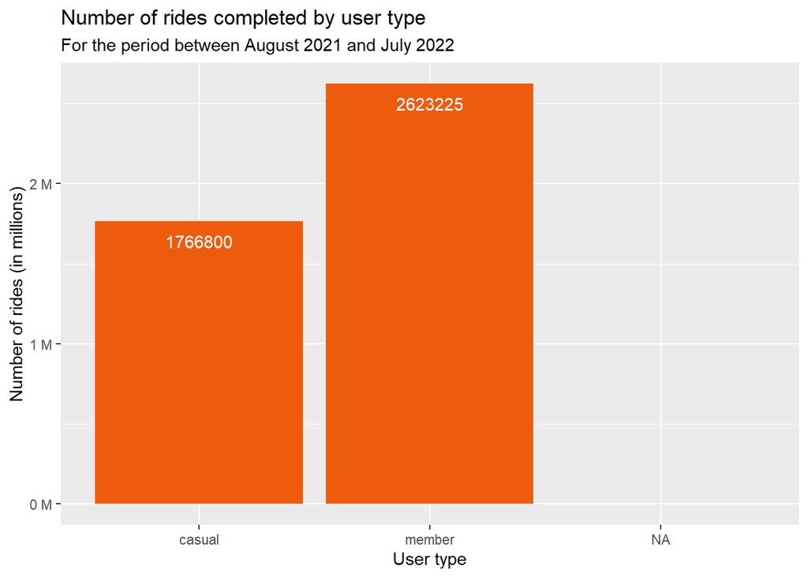

```r
  ggplot(data= all_trips_final, aes(x=customer_type)) +
  geom_bar(fill = "#EF5B0C") +
  labs(
    title = "Number of rides completed by user type",
    subtitle = "For the period between August 2021 and July 2022",
    x = "User type",
    y = "Number of rides (in millions)") +
  scale_y_continuous(labels = label_number(suffix = " M", scale = 1e-6)) +
  geom_text(stat='count', aes(label=..count..), vjust=+2, color="white")
```

### Total Distance (in Km) traveled by the User type

The annual members traveled 1,405,123 kilometers more than the casual riders. When computing this distance between the starting and ending bike station (by long_lat coordinates), it is assumed that the riders traveled from one point to another without making any detours.

Please note that this data may not be entirely accurate because there were 4,076 missing values in distance_km column. This is a result of 4,076 missing values in both end_lat and end_lng column as highlighted in the “Data Preparation” section.

[figure not shown]

```r
distance_travelled <- all_trips_final %>%
  group_by(customer_type) %>%
  summarise(distance_km=sum(distance_km, na.rm=TRUE))

ggplot(distance_travelled, aes(x=customer_type, y=distance_km)) +
  geom_bar(stat = "identity", fill= "#3120E0") +
  labs(
    title = "Distance traveled by user type",
    subtitle = "For the period between August 2021 and July 2022",
    x = "User type",
    y = "Distance traveled (kilometers)") +
  scale_y_continuous(labels = label_number(suffix = " M", scale = 2e-6)) +
  geom_text(aes(label=round(stat(y),2)), vjust=+2, color="white")
```

Although annual members traveled longer total distances, the average distance traveled between annual members and casual riders is roughly the same

```r
average_distance_user_type <- all_trips_final %>%
  group_by(customer_type) %>%
  summarise(average_distance_km=mean(distance_km, na.rm=TRUE))

print(average_distance_user_type)
```

```
## # A tibble: 3 × 2
##   customer_type average_distance_km
##   <chr>                       <dbl>
## 1 casual                       2.23
## 2 member                       2.04
## 3 <NA>                       NaN
```

### How much hour cycled by user type

Annual members cycled 5,398,622 hours less than casual riders.

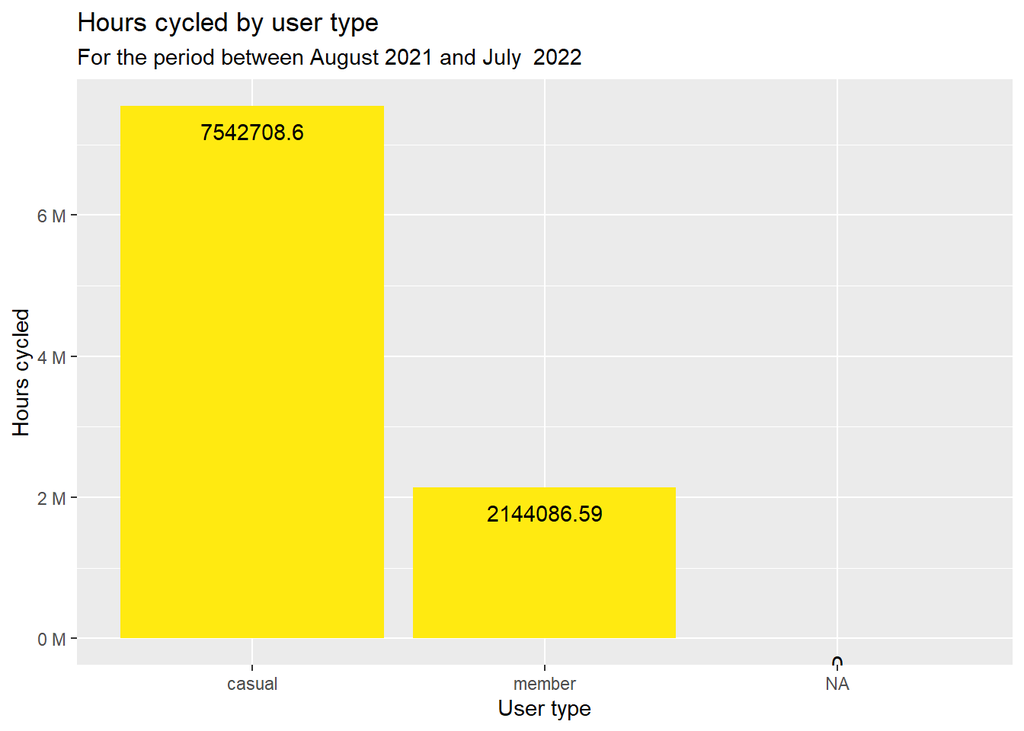

```r
cycling_hour <- all_trips_final %>%
  group_by(customer_type) %>%
  summarise( time_hrs = sum(trip_duration,  na.rm=TRUE))

cycling_hour <- cycling_hour %>%
  group_by(customer_type) %>%  summarise( time_hrs = time_hrs/60)

ggplot(cycling_hour, aes(x=customer_type, y=time_hrs)) +
  geom_bar(stat = "identity", fill = "#FFEA11") +
  labs(
    title = "Hours cycled by user type",
    subtitle = "For the period between August 2021 and July  2022",
    x = "User type",
    y = "Hours cycled") +
  scale_y_continuous(labels = label_number(suffix = " M", scale = 1e-6)) +
  geom_text(aes(label=round(time_hrs,2)), vjust=+2, color="black")
```

### Bike preference by user type

```r
bike_type_preference <- all_trips_final %>%
  group_by(customer_type, ride_type) %>%
  summarise(count_of = n())
```

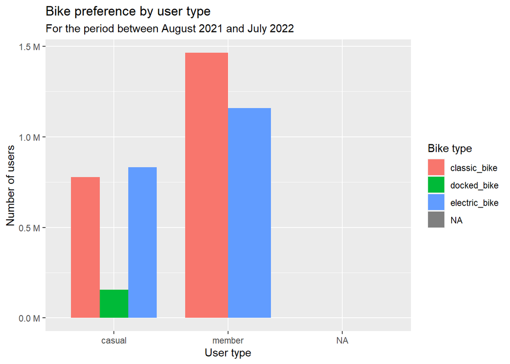

```r
ggplot(bike_type_preference, aes(x=customer_type, y= count_of, fill=ride_type)) +
  geom_bar(stat="identity", position = position_dodge(width = 0.75), width = 0.75 ) +
  labs(
    title = "Bike preference by user type",
    subtitle = "For the period between August 2021 and July 2022",
    fill = "Bike type",
    x = "User type",
    y = "Number of users") +
  scale_y_continuous(labels = label_number(suffix = " M", scale = 1e-6))
```

### Number of rides completed during each day by user type

```r
all_trips_final$day_of_the_week <- ordered(all_trips_final$day_of_the_week, levels=c("Mon", "Tue", "Wed", "Thu", "Fri", "Sat", "Sun"))
all_trips_final$month <- ordered(all_trips_final$month, levels=c("Aug_21", "Sep_21", "Oct_21",
                                                          "Nov_21", "Dec_21", "Jan_22", "Feb_22", "Mar_22",
                                                           "Apr_22", "May_22", "Jun_22", "Jul_22"))
all_trips_final %>%
  group_by(customer_type, day_of_the_week) %>%
  summarise(number_of_rides = n(),average_duration_mins = mean(trip_duration)) %>%
  arrange(customer_type, desc(number_of_rides))
```

```
## # A tibble: 15 × 4
## # Groups:   customer_type [3]
##    customer_type day_of_the_week number_of_rides average_duration_mins
##    <chr>         <ord>                     <int>                 <dbl>
##  1 casual        Sat                      367165                 211.
##  2 casual        Sun                      311008                  34.4
##  3 casual        Fri                      252264                 753.
##  4 casual        Thu                      221343                  26.6
##  5 casual        Wed                      212600                 483.
##  6 casual        Mon                      205849                  29.8
##  7 casual        Tue                      196571                 304.
##  8 member        Wed                      425290                  93.1
##  9 member        Tue                      417308                  60.6
## 10 member        Thu                      406820                  12.2
## 11 member        Fri                      363634                  92.9
## 12 member        Mon                      362365                  12.3
## 13 member        Sat                      345057                  47.1
## 14 member        Sun                      302751                  14.2
## 15 <NA>          <NA>                          1                  NA
```

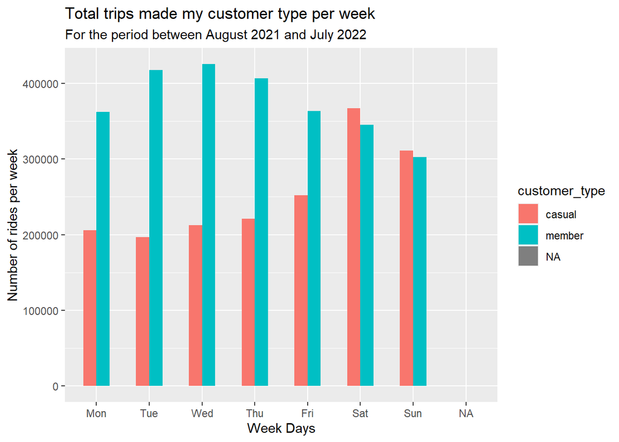

```r
all_trips_final %>%
  group_by(customer_type, day_of_the_week) %>%
  summarise(number_of_rides = n()) %>%
  arrange(customer_type, day_of_the_week)  %>%
  ggplot(aes(x = day_of_the_week, y = number_of_rides, fill = customer_type)) +
  labs(title ="Total trips made my customer type per week",
        subtitle = "For the period between August 2021 and July 2022",
    x = "Week Days",
    y = "Number of rides per week"
       ) +
  geom_col(width=0.5, position = position_dodge(width=0.5)) +
  scale_y_continuous(labels = function(x) format(x, scientific = FALSE))
```

### Number of rides completed during each month by user type

```r
unique(all_trips$month)
```

```
##  [1] "Aug_10" "Aug_21" "Aug_19" "Aug_13" "Aug_17" "Aug_04" "Aug_01" "Aug_05"
##  [9] "Aug_06" "Aug_30" "Aug_16" "Aug_24" "Aug_18" "Aug_08" "Aug_07" "Aug_02"
## [17] "Aug_27" "Aug_28" "Aug_03" "Aug_22" "Aug_14" "Aug_11" "Aug_15" "Aug_29"
## [25] "Aug_12" "Aug_25" "Aug_09" "Aug_31" "Aug_23" "Aug_20" "Aug_26" "Sep_21"
## [33] "Oct_21" "Nov_21" "Dec_21" "Jan_22" "Feb_22" "Mar_22" "Apr_22" "May_22"
## [41] "Jun_22" "Jul_26" "Jul_03" "Jul_31" "Jul_28" "Jul_24" "Jul_04" "Jul_21"
## [49] "Jul_29" "Jul_09" "Jul_08" "Jul_14" "Jul_19" "Jul_07" "Jul_22" "Jul_02"
## [57] "Jul_13" "Jul_01" "Jul_18" "Jul_25" "Jul_30" "Jul_11" "Jul_15" "Jul_20"
## [65] "Jul_23" "Jul_27" "Jul_17" "Jul_16" "Jul_05" "Jul_12" "Jul_06" "Jul_10"
## [73] NA
```

```r
all_trips_final %>%
  group_by(customer_type, month) %>%
  summarise(number_of_rides = n(),`average_duration_(mins)` = mean(trip_duration, na.rm= TRUE)) %>%
  arrange(customer_type,desc(number_of_rides))
```

```
## # A tibble: 27 × 4
## # Groups:   customer_type [3]
##    customer_type month  number_of_rides `average_duration_(mins)`
##    <chr>         <ord>            <int>                     <dbl>
##  1 casual        Jun_22          369044                      32.1
##  2 casual        Sep_21          363883                      27.8
##  3 casual        May_22          280414                      30.9
##  4 casual        Oct_21          257242                      28.7
##  5 casual        Apr_22          126417                      29.5
##  6 casual        Nov_21          106898                      23.1
##  7 casual        Mar_22           89880                      32.6
##  8 casual        Dec_21           69738                      23.5
##  9 casual        <NA>             30045                    4042.
## 10 casual        Feb_22           21416                      26.7
## # … with 17 more rows
## # ℹ Use `print(n = ...)` to see more rows
```

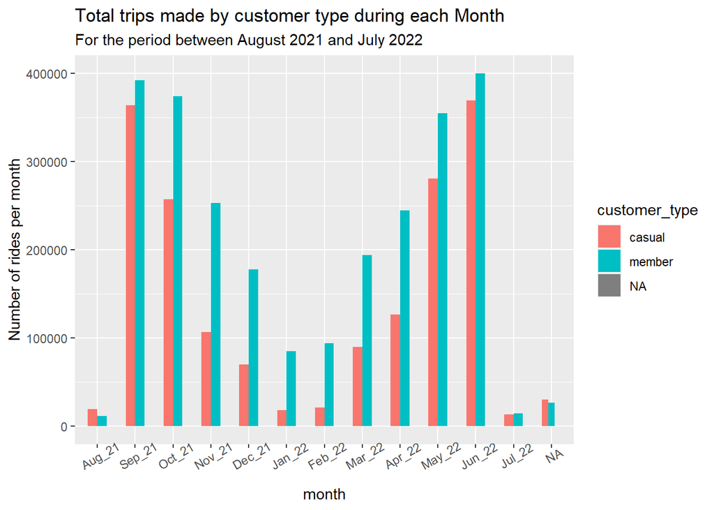

```r
all_trips_final %>%
  group_by(customer_type, month) %>%
  summarise(number_of_rides = n()) %>%
  arrange(customer_type, month)  %>%
  ggplot(aes(x = month, y = number_of_rides, fill = customer_type)) +
  labs(title ="Total trips made by customer type during each Month",
        subtitle = "For the period between August 2021 and July 2022",
    x = "month",
    y = "Number of rides per month"
       ) +
  theme(axis.text.x = element_text(angle = 30)) +
  geom_col(width=0.5, position = position_dodge(width=0.5)) +
  scale_y_continuous(labels = function(x) format(x, scientific = FALSE))
```

### Number of bike demand over 24hr of period (a day)

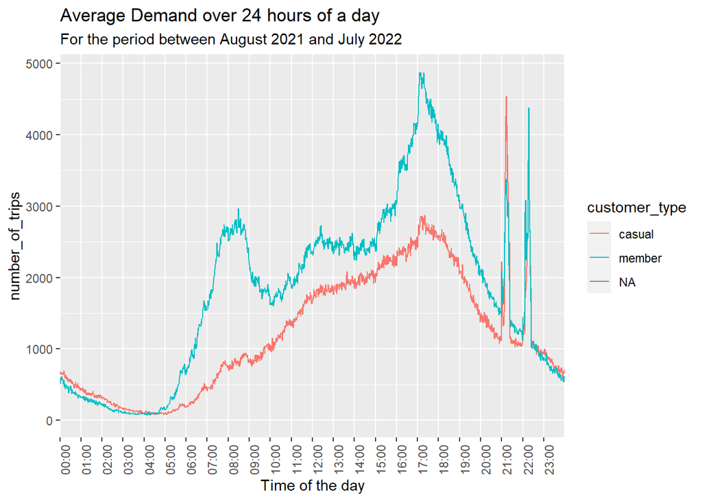

```r
all_trips_final %>%
  group_by(customer_type, time) %>%
  summarise(number_of_trips = n()) %>%
  ggplot(aes(x = time, y = number_of_trips, color = customer_type, group = customer_type)) +
  geom_line() +
  scale_x_datetime(date_breaks = "1 hour", minor_breaks = NULL,
                   date_labels = "%H:%M", expand = c(0,0)) +
  theme(axis.text.x = element_text(angle = 90)) +
  labs(title ="Average Demand over 24 hours of a day",subtitle='For the period between August 2021 and July 2022',Y = 'Number of trips', x = "Time of the day")
```

### Top 5 start stations by user types

```r
top_station <- all_trips_final %>%
  group_by(customer_type, start_station_name) %>%
  summarise(count_of=n()) %>%
  arrange(desc(count_of)) %>%
  na.omit(start_station_name)
  ## Table 1.1 - By casual riders ##
top_station_casual <- filter(top_station, customer_type =="casual") %>%
  rename(number_of_trips = count_of) %>%
  slice(1:5)

  #Table 1.2 - By members ##
top_station_member <- filter(top_station, customer_type =="member") %>%
  rename(number_of_trips = count_of) %>%
  slice(1:5)

print(top_station_casual)
```

```
## # A tibble: 5 × 3
## # Groups:   customer_type [1]
##   customer_type start_station_name                  number_of_trips
##   <chr>         <chr>                                         <int>
## 1 casual        ""                                           272838
## 2 casual        "Streeter Dr & Grand Ave"                     41381
## 3 casual        "DuSable Lake Shore Dr & Monroe St"           22916
## 4 casual        "Millennium Park"                             19883
## 5 casual        "Michigan Ave & Oak St"                       17941
```

```r
print(top_station_member)
```

```
## # A tibble: 5 × 3
## # Groups:   customer_type [1]
##   customer_type start_station_name         number_of_trips
##   <chr>         <chr>                                <int>
## 1 member        ""                                  401740
## 2 member        "Kingsbury St & Kinzie St"           20889
## 3 member        "Ellis Ave & 60th St"                18531
## 4 member        "Clark St & Elm St"                  18428
## 5 member        "Wells St & Concord Ln"              17743
```

### Top 5 end stations by user types

The top five end stations are similar to the top five start stations as described earlier.

```r
top_end_stations <- all_trips_final %>%
  group_by(customer_type, end_station_name) %>%
  summarise(count_of=n()) %>%
  arrange(desc(count_of)) %>%
  na.omit(end_station_name)
  ## table for top_end_stations_casual  - By casual riders ##
top_end_stations_casual <- filter(top_end_stations, customer_type =="casual") %>%
  rename(number_of_trips = count_of) %>%
  slice(1:5)

  #table for top_end_stations_member - By members ##
top_end_stations_member <- filter(top_end_stations, customer_type =="member") %>%
  rename(number_of_trips = count_of) %>%
  slice(1:5)

print(top_end_stations_casual)
```

```
## # A tibble: 5 × 3
## # Groups:   customer_type [1]
##   customer_type end_station_name                    number_of_trips
##   <chr>         <chr>                                         <int>
## 1 casual        ""                                           318006
## 2 casual        "Streeter Dr & Grand Ave"                     42967
## 3 casual        "DuSable Lake Shore Dr & Monroe St"           21012
## 4 casual        "Millennium Park"                             20677
## 5 casual        "Michigan Ave & Oak St"                       19005
```

```r
print(top_end_stations_member)
```

```
## # A tibble: 5 × 3
## # Groups:   customer_type [1]
##   customer_type end_station_name           number_of_trips
##   <chr>         <chr>                                <int>
## 1 member        ""                                  402250
## 2 member        "Kingsbury St & Kinzie St"           20570
## 3 member        "Clark St & Elm St"                  18557
## 4 member        "University Ave & 57th St"           18266
## 5 member        "Wells St & Concord Ln"              18178
```

## 5. Evaluation

#### Recommendation

##### Three key recommendations are proposed to convert casual riders to annual members:

- Identify casual riders who typically start and end their ride sessions near residential areas and offer incentives (e.g. discounts, lucky draws, etc) to * convert them into annual members.
- Offer an annual membership for weekday rental to increase number of annual members.
- Conduct a market survey with the casual riders, asking if they would purchase an annual package if there is a bike station near their residence. If the response is positive, consider identifying key residential areas to build new bike stations.

##### Two other recommendations are proposed to increase sales:

- Partner with tour operators to offer a combination package (e.g. attraction pass + bike pass) to increase number of casual riders.
- Increase marketing campaigns during the summer and Autumn season.

##### Further exploration

- Collect data to assess whether there are sufficient bikes to cater to the demand in the top five bike stations
- Conduct marketing promotions and collect price vs demand data to determine the appropriate price point.
- Occupation of member riders - this data could be used to target non-members who come under similar occupation
- Age and gender profile - Again, this data could be used to study the category of riders who can be targeted for attracting new members.

## 6. Resources

- [Stack Overflow](https://stackoverflow.com/)
- [RDocumentation](https://www.rdocumentation.org/)
- [RStudio](https://community.rstudio.com/) and [Kaggle](https://www.kaggle.com/) community